# Japan-returned students in 東方雜誌

Authorship Analysis

Cécile Armand

2025-03-08

Abstract

This document provides the code for exploring how and by whom the Japan-returned students were discussed in the Chinese periodical *Dongfang zazhi* 東方雜誌 (Eastern Miscellany) from 1905 to 1948.

# Introduction

## Extraction/Curation

```r
# clean authors' names

library(dplyr)
library(tidyr)

liuri_authors <- liuri_clean %>% select(DocId, authors) %>%
  mutate(Author = str_replace_all(authors, "\\[", "")) %>%
  mutate(Author = str_replace_all(Author, "\\]", ""))%>%
  mutate(Author = str_replace_all(Author, "\\'", "")) %>%
  separate_rows(Author, sep = ",\\s*")
```

```r
liuri_authors
```

| DocId | authors | Author |
| --- | --- | --- |
| 1905-2-1-66 | NA | NA |
| 1905-2-10-47 | NA | NA |
| 1905-2-5-64 | NA | NA |
| 1905-2-6-54 | NA | NA |
| 1905-2-7-67 | NA | NA |
| 1905-2-9-37 | NA | NA |
| 1905-2-9-38 | NA | NA |
| 1906-3-11-35 | ['留日學生'] | 留日學生 |
| 1906-3-11-56 | NA | NA |
| 1906-3-3-17 | NA | NA |

[output cut: 98 more lines]

## Basic statistics

```r
liuri_authors %>% group_by(Author) %>% count(sort = TRUE) # number of articles by author
liuri_authors %>% group_by(DocId) %>% count(sort = TRUE) # co-authored articles
```

# Biographical Information

We searched for biographical information on the authors in Chinese Wikipedia and the Who’s Who publications provided by the Institute of Modern History (IMH), Academia Sinica, Taipei.

```r
# Create a function for multiple queries

multiple_search <- function(queries, corpus) {
  results <- histtext::search_documents_ex(queries[1], corpus) %>%
    mutate(Q=queries[1])
  for(q in queries){
    new_result <- histtext::search_documents_ex(q, corpus) %>%
      mutate(Q=q)
    results <- dplyr::bind_rows(results, new_result)
  }
  distinct(results)
}

# Create the list of names to query

liuri_authors_list <- liuri_authors %>% drop_na(Author) %>% filter(!Author == "留日學生") %>% mutate(Queries=str_glue('"{Author}"'))
```

## Wikipedia

```r
library(histtext)

liuri_authors_wiki <- multiple_search(liuri_authors_list$Queries, "wikibio-zh") # 338 results
liuri_authors_wiki <- liuri_authors_wiki %>% group_by(Q) %>% add_tally()

# Eliminate irrelevant results

liuri_list_names <- liuri_authors_list$Author
liuri_list_names <-  paste(liuri_list_names, sep = "", collapse = "|")
liuri_authors_wiki <- liuri_authors_wiki %>% mutate(title_match = str_extract(Title, liuri_list_names))
liuri_authors_wiki <- liuri_authors_wiki %>% group_by(title_match) %>% add_tally()

liuri_authors_wiki_match <- liuri_authors_wiki %>% filter(!is.na(title_match)) # 14 matches

# 14 bios remain
```

```r
liuri_authors_wiki_match
```

| DocId | Date | Title | Source | Q | n | title_match | nn |
| --- | --- | --- | --- | --- | --- | --- | --- |
| 5901014 | 2020/06/01 | 王民質 | wikibio | "民質" | 52 | 民質 | 2 |
| 5957933 | 2020/06/01 | 李民質 | wikibio | "民質" | 52 | 民質 | 2 |
| 2944677 | 2020/06/01 | 馬君實 | wikibio | "君實" | 30 | 君實 | 1 |
| 892975 | 2020/06/01 | 歐漢聲 | wikibio | "漢聲" | 47 | 漢聲 | 2 |
| 1895203 | 2020/06/01 | 江漢聲 | wikibio | "漢聲" | 47 | 漢聲 | 2 |
| 1744694 | 2020/06/01 | 馬伯援 | wikibio | "馬伯援" | 3 | 馬伯援 | 1 |
| 1089203 | 2020/06/01 | 唐有壬 | wikibio | "唐有壬" | 3 | 唐有壬 | 1 |
| 246962 | 2020/06/01 | 何西亞 | wikibio | "何西亞" | 2 | 何西亞 | 1 |
| 6319409 | 2020/06/01 | 朱正廷 | wikibio | "朱正" | 20 | 朱正 | 5 |
| 3408586 | 2020/06/01 | 朱正栩 | wikibio | "朱正" | 20 | 朱正 | 5 |

[output cut: 4 more lines]

```r
# Extract the full text of biographies

liuri_authors_wiki_ft <- histtext::get_documents(liuri_authors_wiki_match, "wikibio-zh")
```

```r
liuri_authors_wiki_ft
```

| DocId | Date | Title | Source | Text |
| --- | --- | --- | --- | --- |
| 5901014 | 2020/06/01 | 王民質 | wikibio | \n王民質（？－？），字□實，山西大同府應州人，民籍，明朝政治人物。\n山西鄉試第四十名舉人。弘治十八年（1505年）中式乙丑科三甲第八十五名進士[1][2]。\n曾祖王顯；祖父王□，□□；父王□，□□。母鄭氏[3]。\n |
| 5957933 | 2020/06/01 | 李民質 | wikibio | \n李民質（？－？），字元素，直隸大名府東明縣人，軍籍，明朝政治人物。\n順天府鄉試第二十六名，萬曆十一年（1583年）癸未科會試第三百三十一名，登二甲第四十六名進士[1][2]。\n曾祖李鐸；祖父李厚；父李璇。母簡氏[3]。\n |
| 2944677 | 2020/06/01 | 馬君實 | wikibio | \n參數所指定的目標頁面不存在，建議更正成存在頁面或直接建立下列一個頁面（建立前請先搜尋是否有合適的存在頁面可以取代）：\n馬君實（1876年－1926年），又名馬君寔、后改名馬振憲，字冀平，号寄翁，又号无寄，安徽省桐城縣市乡（後为桐城縣城关镇）人。清朝及中华民国政治人物、诗人、佛教居士，進士出身。[1]\n馬君實出身名门。高祖马宗琏、曾祖马瑞辰，皆治汉学。祖马三俊，举孝廉方正。父马复恒，辅佐丁汝… |
| 892975 | 2020/06/01 | 歐漢聲 | wikibio | \n歐漢聲（1979年7月4日－），本名歐陽漢聲[4]，暱稱歐弟，為臺灣節目主持人、歌手、演員。1996年，以男子團體「四大天王」出道，然而因當中兩位團員入伍服役而宣告解散。1998年，與羅志祥另組團體「羅密歐」，亦因其入伍而解散。退伍之後，歐漢聲以個人姿態在娛樂圈活動至今。除了主持和歌唱，他亦擅長模仿、舞蹈和B-Box，是台灣電視主持人胡瓜的徒弟，也是臺灣赴中國大陸發展相當成功的主持人。歐漢聲數… |
| 1895203 | 2020/06/01 | 江漢聲 | wikibio | \n江漢聲（1950年3月26日－），臺灣醫學學者，泌尿科醫師，臺灣性教育協會共同創辦人。現任天主教輔仁大學校長，國立臺灣大學、臺北醫學大學兼任教授，中華民國大專院校體育總會（大專體總）會長，亞洲基督教大學協會理事長，台灣基督宗教大學校院聯盟理事長。\n現任臺北醫學大學附設醫院泌尿科兼任主治醫師，2009年11月開始在輔大診所看診[2]。\n其目差於輔大醫學院的2所教學醫院－－耕莘醫院、新光醫院擔… |
| 1744694 | 2020/06/01 | 馬伯援 | wikibio | \n马伯援（1884年－1939年），又名发祥，字吉楷，湖北枣阳鹿头镇人。中国民主革命家，中华民国政治人物。\n1905年，马伯援考入新军左旗学习军事，此后不久到日本留学，并加入中国同盟会。1910年，他从早稻田大学政治系毕业。辛亥革命期间，马伯援曾经率领红十字会员护送黄兴、宋教仁等人从上海到武昌，并参加了汉阳战役，担任黎元洪的顾问。1911年12月29日，他作为各省都督府代表聯合會的湖北代表，参… |
| 1089203 | 2020/06/01 | 唐有壬 | wikibio | \n唐有壬（1894年－1935年12月25日）[1]，字寿田，湖南省浏阳县人，唐才常三子[2]。中华民国政治人物、外交官。\n唐有壬生于光绪二十年（1894年）[2]。6岁时，父亲唐才常因自立军起义失败而遇难。清朝末年，唐有壬肄業於長沙的湖南高等實業學堂。受到焦达峰、陈作新等革命者影响，唐有壬具有爱国思想。1911年10月21日夜，唐有壬缮写数十张檄文，张贴在街道上。辛亥革命之後，作为辛亥革命烈… |
| 246962 | 2020/06/01 | 何西亞 | wikibio | \n何西阿，天主教译为欧瑟亚 (Hosea) 是《聖經‧舊約全書》裡何西阿書一卷的作者，他是公元前8世紀的一位先知，父親備利(Belee)亦是當時的一位先知。他依照上帝的說話，娶了歌蔑為妻，並育有數名子女。後來歌蔑果然正如上帝所言，拋夫棄子私奔去，但何西亞依然期待著她回來。果然後來歌蔑的確重新回來。上帝希望藉著這一件事來預言，雖然以色列人會離棄上帝，但上帝依然期待他們的回心轉意。\n |
| 6319409 | 2020/06/01 | 朱正廷 | wikibio | \n朱正廷（Zhu Zheng-ting，1996年3月18日－），安徽馬鞍山人，中國大陸男歌手、演員。2017年參加韓國Mnet選秀節目《PRODUCE 101 第二季》，並於2018年4月6日在爱奇藝《偶像練習生》最終以第6名成為限定男團NINE PERCENT成員出道[16][17]，同年6月21日，與同公司練習生組成乐华七子NEXT且擔任隊長[14]，在兩團中皆擔當主舞、副唱。\n朱正廷出… |
| 3408586 | 2020/06/01 | 朱正栩 | wikibio | \n朱正栩（1974年－），河南宝丰人，汉族，中华人民共和国政治人物、第十二届全国人民代表大会河南地区代表。\n毕业于河南师范大学法学专业。加入中国共产党。2013年，担任全国人大代表[1]。\n |

[output cut: 4 more lines]

## Who’s Who (IMH collection)

```r
library(histtext)

liuri_authors_imh <- multiple_search(liuri_authors_list$Queries, "imh-zh") # 117 results

liuri_authors_imh <- liuri_authors_imh %>% mutate(title_match = str_extract(Title, liuri_list_names))
liuri_authors_imh <- liuri_authors_imh %>% group_by(title_match) %>% add_tally()

# Eliminate irrelevant results

liuri_authors_imh_match <- liuri_authors_imh %>% filter(!is.na(title_match)) #  69 results remain

liuri_authors_imh_match <- liuri_authors_imh_match %>% distinct(DocId, Title) %>%
  mutate(Title_clean = str_replace(Title, "【", ""))  %>%
  mutate(Title_clean = str_replace(Title_clean, "】", "")) %>%
  mutate(Title_clean = str_extract(Title_clean, "^.{3}")) %>% relocate(title_match, .after = Title_clean)

liuri_authors_imh_match <- liuri_authors_imh_match %>% mutate(title_length = nchar(Title)) %>% mutate(title_length2 = nchar(Title_clean)) %>%
  mutate(query_length = nchar(title_match)) %>% mutate(dif = (query_length-title_length))  %>% mutate(dif2 = (query_length-title_length2))

liuri_authors_imh_filtered <- liuri_authors_imh_match %>% filter(!dif2 == "-1")

liuri_authors_imh_unique <- liuri_authors_imh_filtered %>%
  select(DocId, title_match) %>% rename(Name = title_match) %>%
  group_by(Name) %>% count()

liuri_authors_imh_filtered <- liuri_authors_imh_filtered %>% select(DocId, title_match) %>% rename(Name = title_match)

# 49 biographies remain, referring to 13 unique names (from 1 to 6 biographies per author)
```

```r
liuri_authors_imh_filtered
```

| DocId | Name |
| --- | --- |
| imh-05-8482 | 周由廑 |
| imh-51-228 | 王桐齡 |
| imh-54-55 | 王桐齡 |
| imh-14-224 | 王桐齡 |
| imh-16-1635 | 王桐齡 |
| imh-47-154 | 馬伯援 |
| imh-51-1987 | 馬伯援 |
| imh-54-1153 | 馬伯援 |
| imh-51-1055 | 李權時 |
| imh-47-1359 | 李權時 |

[output cut: 39 more lines]

```r
# Retrieve full text

liuri_authors_imh_ft <- histtext::get_documents(liuri_authors_imh_filtered, "imh-zh")
```

```r
liuri_authors_imh_ft
```

| DocId | Date | Title | Source | Text |
| --- | --- | --- | --- | --- |
| imh-05-8482 | 1941 | 周由廑 | 上海人名錄 | 周由廑\n西摩路八一五弄六號 電話：三七六七八 |
| imh-51-228 | 1940 | 王桐齡 | 中國文化界人物總鑑 | 王桐齡\n嶧山\n河北任邱\n1878-X\n |
| imh-54-55 | 1942 | 王桐齡 | 日本留學支那要人錄 | 王桐齡\n嶧山\n河北省任邱\n1879\n |
| imh-14-224 | 1931 | 王桐齡 | 當代中國名人錄 | 王桐齡\n字嶧山。\n年五十二歲。\n河北任邱人。\n日本東京帝國大學文學士。\n歷任教育部參事、北京高等師範學校教務主任、國立北京師範大學教授、國立北京女子師範大學、國立北京法政大學、明德大學及中國大學講師、志成中學校校長、燕京大學教授。現任國立淸華大學歷史學系講師、國立北京大學史學系講師。著有史學書多種。\n |
| imh-16-1635 | 1936 | 王桐齡 | 中華民國名人傳 | (566)下冊-學術-14王桐齡\n王桐齡，字嶧山，河北任邱縣人。家世業儒，少孤，治帖括業。五世從祖應鯨\n，爲有淸中葉學者，長於考據，著有朱子資治通鑑綱目註義一書。王家有藏版\n，心好之，時涉獵焉。弱冠，入汼。値戊戌政變，亟欲知世界大勢，始涉獵家\n藏舊書及譯本新書。庚子變後，政府始提倡新學，王考入直隸大學堂肄業。旋\n升入北京大學堂師範館肄業。以成績優良，派往日本留學，入第一高等學校第\n一部… |
| imh-47-154 | 1928 | 馬伯援 | 現代支那人名鑑 | 馬伯援\nMa Po-yüan\n東京 |
| imh-51-1987 | 1940 | 馬伯援 | 中國文化界人物總鑑 | 馬伯援\n告階\n湖北棗陽\n1885-X\n |
| imh-54-1153 | 1942 | 馬伯援 | 日本留學支那要人錄 | 馬伯援\n告階\n湖北省棗陽\n1885\n |
| imh-51-1055 | 1940 | 李權時 | 中國文化界人物總鑑 | 李權時\n雨生\n浙江鎭海\n1895-X\n |
| imh-47-1359 | 1928 | 李權時 | 現代支那人名鑑 | 李權時\n雨生\nLi Ch'un-shih\n浙江省鎭海縣\n上海 |

[output cut: 39 more lines]

## Biographical Attributes

```r
## Bind the two datasets

liuri_authors_bio <- bind_rows(liuri_authors_imh_ft, liuri_authors_wiki_ft)
```

### Year of Birth

```r
# Retrieve year of birth

liuri_authors_bio$year <- regmatches(liuri_authors_bio$Text, gregexpr("\\d{4}", liuri_authors_bio$Text))
liuri_authors_bio$birth <- regmatches(liuri_authors_bio$year, regexpr("[[:digit:]]+", liuri_authors_bio$year))
liuri_authors_bio$year <- NULL
liuri_authors_bio_filtered <- liuri_authors_bio %>% filter(birth < 1948) %>% filter(birth > 1800) # 20 names remain
```

```r
liuri_authors_bio_filtered
```

[output not shown]

[output cut: 10 more lines]

### Native Place

```r
# Retrieve native provinces based on list

library(readr)
provinces <- read_delim("~/indexes/provinces.csv",
                       delim = ";", escape_double = FALSE, trim_ws = TRUE)

provinces <- provinces %>% na.omit()

# create vector

prov_list <- provinces$Province
prov_list <-  paste(prov_list, sep = "", collapse = "|")
liuri_authors_bio_filtered <- liuri_authors_bio_filtered %>% mutate(birthplace = str_extract(Text, prov_list))
```

### Education

```r
# Retrieve academic disciplines based on typology

# Load typology

library(readr)
disciplines <- read_delim("~/indexes/disciplines.csv",
                                    delim = ";", escape_double = FALSE, trim_ws = TRUE)

# create vector

disc_list <- disciplines$Level2__ZhT_MCBD
disc_vec <-  paste(disc_list, sep = "", collapse = "|")

liuri_authors_bio_filtered <- liuri_authors_bio_filtered %>%
  mutate(discipline = str_extract_all(Text, disc_vec)) %>%
  mutate(discipline = as.character(discipline))
```

```r
# identify those who studied or traveled to foreign countries

liuri_authors_bio_filtered <- liuri_authors_bio_filtered %>%
  mutate(edu_country = str_extract_all(Text, "留美|留日|留法|留德|留英")) %>%
  mutate(edu_country = as.character(edu_country)) %>%
  mutate(country = str_extract_all(Text, "美國|日本|法國|德國|英國")) %>%
  mutate(country = as.character(country))
```

```r
liuri_authors_bio_filtered
```

| DocId | Date | Title | Source | Text | birth | birthplace | discipline | edu_country | country |
| --- | --- | --- | --- | --- | --- | --- | --- | --- | --- |
| imh-51-228 | 1940 | 王桐齡 | 中國文化界人物總鑑 | 王桐齡\n嶧山\n河北任邱\n1878-X\n | 1878 | 河北 | character(0) | character(0) | character(0) |
| imh-54-55 | 1942 | 王桐齡 | 日本留學支那要人錄 | 王桐齡\n嶧山\n河北省任邱\n1879\n | 1879 | 河北 | character(0) | character(0) | character(0) |
| imh-51-1987 | 1940 | 馬伯援 | 中國文化界人物總鑑 | 馬伯援\n告階\n湖北棗陽\n1885-X\n | 1885 | 湖北 | character(0) | character(0) | character(0) |
| imh-54-1153 | 1942 | 馬伯援 | 日本留學支那要人錄 | 馬伯援\n告階\n湖北省棗陽\n1885\n | 1885 | 湖北 | character(0) | character(0) | character(0) |
| imh-51-1055 | 1940 | 李權時 | 中國文化界人物總鑑 | 李權時\n雨生\n浙江鎭海\n1895-X\n | 1895 | 浙江 | character(0) | character(0) | character(0) |
| imh-03-328 | 1936 | 李權時 | 上海工商人名錄 | 李權時\n雨生\n年四十二歲（公曆1895年生）。\n美國哥倫比亞大學哲學博士。\n現為復旦大學商學院院長、銀行週報社經理兼編輯。\n | 1895 | NA | c("哲學", "銀行") | character(0) | 美國 |
| imh-54-1097 | 1942 | 唐有壬 | 日本留學支那要人錄 | 唐有壬\n壽田\n湖南省瀏陽\n1897\n | 1897 | 湖南 | character(0) | character(0) | character(0) |
| imh-72-2171 | UNK | 唐有壬 | 外交檔案人物 | 唐有壬\n、Tang Yu-jen\n\n■學經歷時間職務出處備註民國23.2.21(1934.02.21) 國民政府外交部常務次長 民國職官年表, p.519-520 民國24.12(1935.12) 國民政府外交部常務次長 民國職官年表, p.519-520 \n\n■相關連結檔案館館藏檢索系統\n檔案館人名權威檢索系統\n■譯名：Tang Yu-jen 生年：1894 卒年：193512 國… | 1934 | 湖南 | c("外交", "外交", "外交", "財政", "銀行", "經濟", "政治", "外交", "外交") | character(0) | 日本 |
| imh-51-1656 | 1940 | 胡先驌 | 中國文化界人物總鑑 | 胡先驌\n步曾\n江西南昌\n1894-X\n | 1894 | 江西 | character(0) | character(0) | character(0) |
| imh-51-1370 | 1940 | 周孝庵 | 中國文化界人物總鑑 | 周孝庵\n江蘇靑浦\n1900-X\n | 1900 | 江蘇 | character(0) | character(0) | character(0) |

[output cut: 10 more lines]

## Named Entity Recognition (NER)

In the following section, we extract named entities from biographies using [models specifically developed by the ENP-China team](https://bookdown.enpchina.eu/HistText_Book/named-entity-recognition-ner.html) for modern Chinese historical texts, integrated into the HistText package.

### Extraction

```r
liuri_authors_imh_ner <- ner_on_corpus(liuri_authors_imh_ft, corpus = "imh-zh")
liuri_authors_wiki_ner <- ner_on_corpus(liuri_authors_wiki_ft, corpus = "wikibio-zh")
liuri_authors_ner <- bind_rows(liuri_authors_imh_ner, liuri_authors_wiki_ner) # bind the two lists
```

```r
liuri_authors_ner
```

| DocId | Type | Text | Start | End | Confidence |
| --- | --- | --- | --- | --- | --- |
| imh-05-8482 | FAC | 西摩路 | 4 | 7 | -1 |
| imh-51-228 | PERSON | 王桐齡 | 0 | 3 | -1 |
| imh-51-228 | PERSON | 任邱 | 9 | 11 | -1 |
| imh-51-228 | CARDINAL | 1878 | 12 | 16 | -1 |
| imh-54-55 | PERSON | 王桐齡 | 0 | 3 | -1 |
| imh-54-55 | GPE | 河北省 | 7 | 10 | -1 |
| imh-54-55 | PERSON | 任邱 | 10 | 12 | -1 |
| imh-54-55 | DATE | 1879 | 13 | 17 | -1 |
| imh-14-224 | PERSON | 王桐齡 | 0 | 3 | -1 |
| imh-14-224 | DATE | 五十二歲 | 10 | 14 | -1 |

[output cut: 3310 more lines]

In the following section, we focus on organizations to define occupational profiles, but we could also examine other types of entities, such as events in which they were involved or creative works they produced during their careers.

### Curation

```r
# Filter organizations

liuri_authors_org <- liuri_authors_ner %>% filter(Type == "ORG")

# Preliminary cleaning

liuri_authors_org <- liuri_authors_org %>%
  mutate(text_clean = str_replace(Text, "《", "")) %>%
  mutate(text_clean = str_replace(text_clean, ">", "")) %>%
  relocate(text_clean, .after = Text) %>%
  mutate(text_clean, text_clean=str_replace(text_clean,"（.*","")) %>%
  mutate(text_clean, text_clean=str_replace(text_clean,"\\(.*","")) %>%
  mutate(text_clean, text_clean=str_replace(text_clean,"\\(.*",""))%>%
  mutate(text_clean = str_replace(text_clean, " ", "")) %>%
  mutate(text_clean = str_replace(text_clean, " ", ""))%>%
  mutate(length = nchar(text_clean)) %>%
  relocate(length, .after = text_clean)

liuri_authors_org <- liuri_authors_org %>% filter(length > 1) # 463

# Extract suffixes and prefixes to help classify and locate institutions

liuri_authors_org <- liuri_authors_org %>%
  mutate(class = str_sub(text_clean,-2,-1)) %>%
  relocate(class, .after = text_clean)

liuri_authors_org <- liuri_authors_org %>%
  mutate(pre = str_sub(text_clean, 1, 2)) %>%
  relocate(pre, .before = text_clean)

# Remove residual noise (position verbs, etc)

liuri_authors_org <- liuri_authors_org %>%
  mutate(text_clean = str_replace(text_clean, "任", ""))%>%
  mutate(text_clean = str_replace(text_clean, "入", ""))%>%
  mutate(text_clean = str_replace(text_clean, "久", ""))%>%
  mutate(text_clean = str_replace(text_clean, "于", ""))%>%
  mutate(text_clean = str_replace(text_clean, "於", ""))%>%
  mutate(text_clean =  str_replace(text_clean, "從", "")) %>%
  mutate(length = nchar(text_clean)) %>%
  filter(length > 1) %>% #
  mutate(pre = str_sub(text_clean, 1, 2))

liuri_authors_org <- liuri_authors_org %>%
  filter(stringr::str_detect(liuri_authors_org$text_clean, "[\\p{Han}]"))

# 461 organizations remain
```

### Basic statistics

```r
# Most important institutions (altogether, across biographies)

liuri_authors_org %>% group_by(text_clean) %>%
  count(sort = TRUE)
```

| text_clean | n |
| --- | --- |
| 中國現代史辭典 | 16 |
| 外交部 | 8 |
| 立法院 | 8 |
| 華東軍政委員會文化教育委員 | 6 |
| 中华青年抗日除奸团 | 5 |
| 教育部 | 5 |
| 行政院 | 4 |
| 中国国民党 | 3 |
| 中央 | 3 |
| 中視 | 3 |

[output cut: 340 more lines]

```r
liuri_authors_org %>% distinct(DocId, text_clean) %>%
  group_by(text_clean) %>% count(sort = TRUE)
```

| text_clean | n |
| --- | --- |
| 教育部 | 4 |
| 中央 | 3 |
| 光華大學 | 3 |
| 立法院 | 3 |
| 行政院 | 3 |
| 中共 | 2 |
| 中国共产党 | 2 |
| 中国国民党 | 2 |
| 中國公學 | 2 |
| 中央銀行金融機構業務檢查處 | 2 |

[output cut: 340 more lines]

```r
# Most important types of institutions

liuri_authors_org %>% distinct(DocId, text_clean, class) %>%
  group_by(class) %>% count(sort = TRUE)
```

| class | n |
| --- | --- |
| 大學 | 55 |
| 學院 | 13 |
| 員會 | 8 |
| 學校 | 8 |
| 球隊 | 8 |
| 政府 | 7 |
| 足球 | 7 |
| 法院 | 6 |
| 中央 | 5 |
| 政會 | 5 |

[output cut: 192 more lines]

Finally, we export the list of authors with extracted information for manual verification to remove redundant or irrelevant results. We also export the list of organizational affiliations to standardize and categorize the authors and their occupations.

```r
write.csv(liuri_authors_org, "~/output/liuri_authors_org.csv")
write.csv(liuri_authors_bio_filtered, "~/output/liuri_authors_bio_filtered.csv")
```

## Univariate Analyses

```r
# Reimport curated list of authors and their attributes

library(readr)
liuri_authors_to_analyze <- read_delim("~/liuri_authors_to_analyze.csv",
                                       delim = ";", escape_double = FALSE, trim_ws = TRUE)

# Replace empty fields with NAs

liuri_authors_to_analyze <-liuri_authors_to_analyze %>%
  mutate(across(everything(), ~ifelse(.=="", NA, as.character(.))))
```

```r
liuri_authors_to_analyze
```

| Name | Pinyin | 筆名 | Nationality | Birthplace | BirthYear | DeathYear | Generation | Education Country | Country of Education | Occupation | Occupation2 | Party | Specialization | Corpus | Sentiment | Topic |
| --- | --- | --- | --- | --- | --- | --- | --- | --- | --- | --- | --- | --- | --- | --- | --- | --- |
| 張梓生 | Zhang Zisheng | NA | Chinese | 浙江 | 1892 | 1967 | Pre1895 | China-NA | China | professional writer | journalist | NA | editor, journalist, and publisher | liuri | Negative | T1. Sino-Japanese Tensions |
| 馬伯援 | Ma Boyuan | NA | Chinese | 湖北 | 1884 | 1939 | Pre1895 | Japan-USA | Japan, USA | official-bureaucrat | military | TMH-GMD | politician | liuri | Negative | T1. Sino-Japanese Tensions |
| 吳德彰 | Wu Dezhang | NA | Chinese | NA | NA | NA | Pre1895 | China-NA | NA | NA | NA | NA | NA | liuri | Positive | T2. Education/Political Reforms |
| 傖父 | Cang Fu | NA | Chinese | NA | NA | NA | Pre1895 | China-NA | NA | NA | NA | NA | NA | liuri | Positive | T2. Education/Political Reforms |
| 姚振華 | Yao Zhenhua | NA | Chinese | NA | NA | NA | Pre1895 | China-NA | NA | professional writer | translator | NA | translator | liuri | Negative | T2. Education/Political Reforms |
| 蔣維喬 | Jiang Weijiao | NA | Chinese | 江蘇 | 1874 | 1958 | Pre1895 | China-NA | China | scholar | humanities | NA | philosopher, educator, Buddhist scholar | liuri | Negative | T2. Education/Political Reforms |
| 朱經農 | Zhu Jingnong | NA | Chinese | 江蘇 | 1887 | 1951 | Pre1895 | Japan | Japan | scholar-official | social sciences | NA | scholar, educator and government official | liuri | Positive | T2. Education/Political Reforms |
| 周由廑 | Zhou Youjin | T. T. Eugene Tseu | Chinese | 浙江 | 1882 | NA | Pre1895 | China-NA | China | scholar | humanities | NA | educator and writer | liuri | Positive | T2. Education/Political Reforms |
| 唐有壬 | Tang Youren | NA | Chinese | 湖南 | 1894 | 1935 | Pre1895 | Japan | Japan | official-bureaucrat | diplomacy | GMD | politician, diplomat | liuri | Negative | T3. Regulations/Petitions |
| 民質 | Min Zhi | NA | Chinese | NA | NA | NA | Pre1895 | China-NA | NA | NA | NA | NA | NA | liuri | Negative | T4. Diplomacy/Cultural Exchanges |

[output cut: 32 more lines]

### Nationality

```r
liuri_authors_to_analyze %>% group_by(Nationality) %>% count(sort = TRUE)
```

| Nationality | n |
| --- | --- |
| Chinese | 40 |
| Japanese | 1 |
| NA | 1 |

### Generation

```r
liuri_authors_to_analyze %>% group_by(Generation) %>% count()
```

| Generation | n |
| --- | --- |
| Post1895 | 21 |
| Pre1895 | 17 |
| NA | 4 |

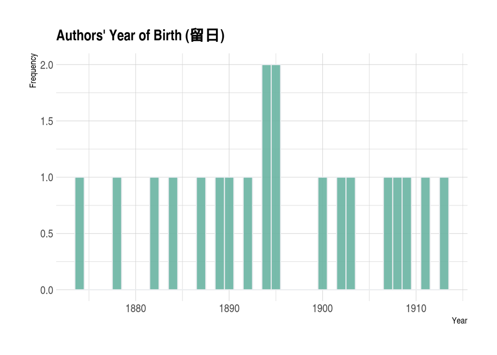

```r
library(hrbrthemes)
library(viridis)

liuri_authors_to_analyze %>% drop_na(BirthYear) %>%
  mutate(BirthYear = as.numeric(BirthYear))%>%
  ggplot( aes(x=BirthYear)) +
  geom_histogram( binwidth=1, fill="#69b3a2", color="#e9ecef", alpha=0.9) +
  ggtitle("Bin size = 1") +
  theme_ipsum() +
  theme(
    plot.title = element_text(size=15)
  ) +
  labs(title = "Authors' Year of Birth (留日)",
       x = "Year",
       y = "Frequency")
```

### Native Place

```r
liuri_authors_to_analyze %>% group_by(Birthplace) %>% count(sort = TRUE)
```

| Birthplace | n |
| --- | --- |
| NA | 22 |
| 浙江 | 6 |
| 江蘇 | 5 |
| 福建 | 3 |
| 江西 | 2 |
| 湖北 | 2 |
| 河北 | 1 |
| 湖南 | 1 |

### Country of education

```r
liuri_authors_to_analyze %>% group_by('Country of Education') %>% count(sort = TRUE)
```

| "Country of Education" | n |
| --- | --- |
| Country of Education | 42 |

```r
liuri_authors_to_analyze %>% group_by('Education Country') %>% count(sort = TRUE)
```

| "Education Country" | n |
| --- | --- |
| Education Country | 42 |

### Professional background

```r
liuri_authors_to_analyze %>% group_by(Occupation) %>% count(sort = TRUE)
```

| Occupation | n |
| --- | --- |
| NA | 18 |
| scholar | 12 |
| professional writer | 6 |
| official-bureaucrat | 4 |
| other | 1 |
| scholar-official | 1 |

```r
liuri_authors_to_analyze %>% group_by(Occupation2) %>% count(sort = TRUE)
```

| Occupation2 | n |
| --- | --- |
| NA | 18 |
| humanities | 6 |
| social sciences | 6 |
| editor, publisher | 3 |
| journalist | 2 |
| diplomacy | 1 |
| finance | 1 |
| legislative | 1 |
| military | 1 |
| movie industry | 1 |

[output cut: 2 more lines]

```r
liuri_authors_to_analyze %>% group_by(Specialization) %>% count(sort = TRUE)
```

| Specialization | n |
| --- | --- |
| NA | 18 |
| economist | 2 |
| politician | 2 |
| botanist, educator, cultural scholar | 1 |
| editor, journalist, and publisher | 1 |
| editor, publisher | 1 |
| editor, scholar | 1 |
| educator and writer | 1 |
| historian | 1 |
| intellectual, writer, philosopher | 1 |

[output cut: 13 more lines]

### Political Affiliation

```r
liuri_authors_to_analyze %>% group_by(Party) %>% count(sort = TRUE)
```

| Party | n |
| --- | --- |
| NA | 38 |
| TMH-GMD | 2 |
| DL | 1 |
| GMD | 1 |

**Note**: DL = Democratic League. GMD = Guomindang. TMH = Tongmenghui.

# Multiple Correspondance Analysis (MCA)

## Data Preparation

```r
liuri_mca <- liuri_authors_to_analyze %>% select(Name, Generation, 'Education Country', Occupation, Sentiment, Topic)
liuri_mca <-  liuri_mca %>% drop_na(Generation) # 38 remain
liuri_mca <- column_to_rownames(liuri_mca, "Name")
```

```r
liuri_mca
```

|  | Generation | Education Country | Occupation | Sentiment | Topic |
| --- | --- | --- | --- | --- | --- |
| 張梓生 | Pre1895 | China-NA | professional writer | Negative | T1. Sino-Japanese Tensions |
| 馬伯援 | Pre1895 | Japan-USA | official-bureaucrat | Negative | T1. Sino-Japanese Tensions |
| 吳德彰 | Pre1895 | China-NA | NA | Positive | T2. Education/Political Reforms |
| 傖父 | Pre1895 | China-NA | NA | Positive | T2. Education/Political Reforms |
| 姚振華 | Pre1895 | China-NA | professional writer | Negative | T2. Education/Political Reforms |
| 蔣維喬 | Pre1895 | China-NA | scholar | Negative | T2. Education/Political Reforms |
| 朱經農 | Pre1895 | Japan | scholar-official | Positive | T2. Education/Political Reforms |
| 周由廑 | Pre1895 | China-NA | scholar | Positive | T2. Education/Political Reforms |
| 唐有壬 | Pre1895 | Japan | official-bureaucrat | Negative | T3. Regulations/Petitions |
| 民質 | Pre1895 | China-NA | NA | Negative | T4. Diplomacy/Cultural Exchanges |

[output cut: 28 more lines]

## MCA

```r
library(FactoMineR)
res.MCA<-MCA(liuri_mca,graph=FALSE)
```

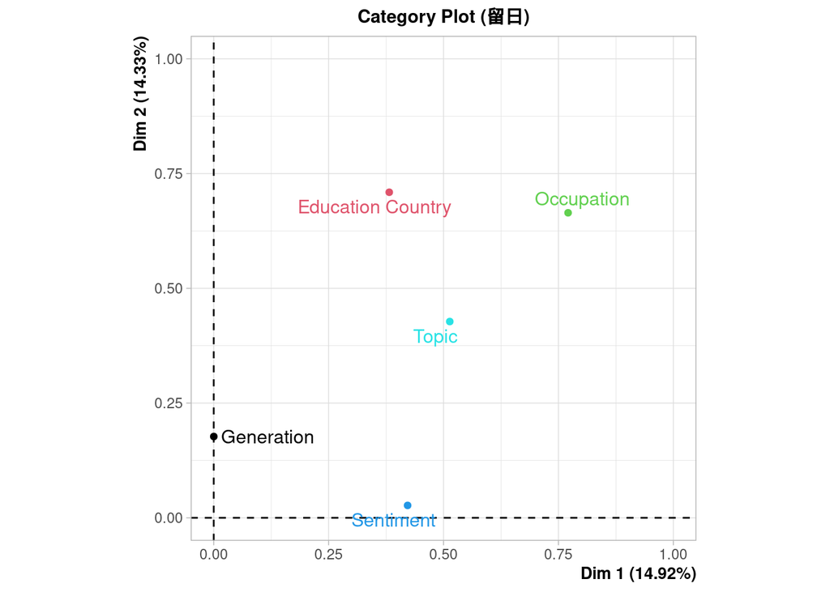

```r
# Plot

plot.MCA(res.MCA, choix='var',title="Category Plot (留日)",col.var=c(1,2,3,4,5))
```

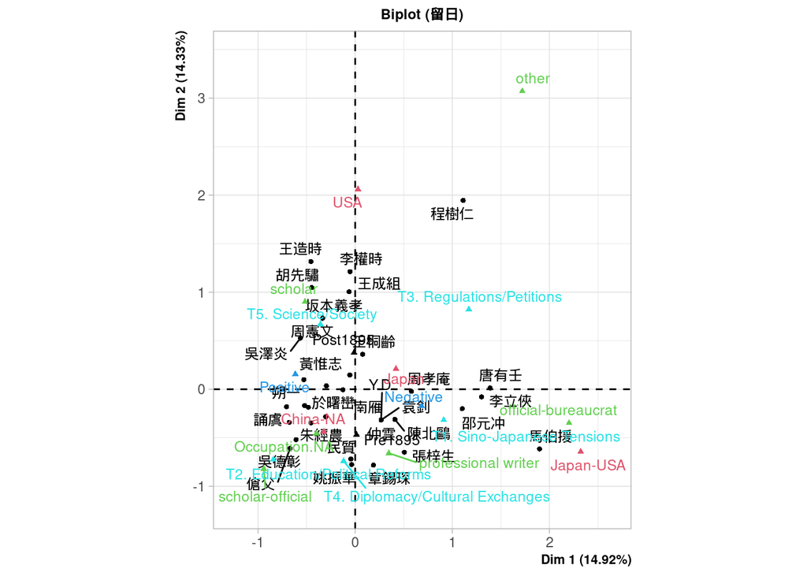

```r
plot.MCA(res.MCA,col.var=c(1,1,2,2,2,2,3,3,3,3,3,3,4,4,5,5,5,5,5),title="Biplot (留日)", cex=0.8,cex.main=0.8,cex.axis=0.8, autoLab = "yes", label =c('ind','var'))
```

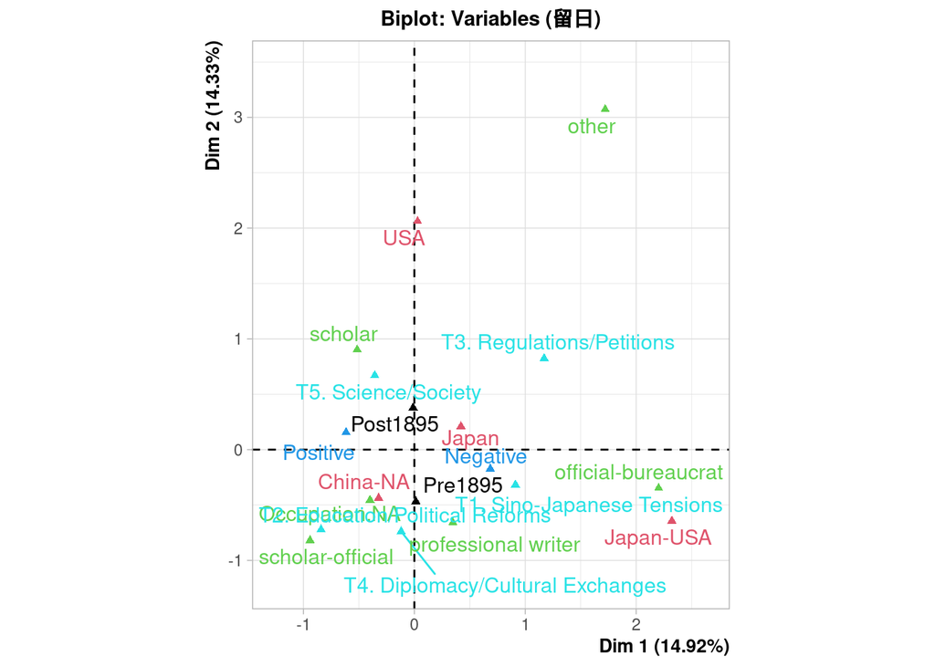

```r
plot.MCA(res.MCA,invisible= 'ind',col.var=c(1,1,2,2,2,2,3,3,3,3,3,3,4,4,5,5,5,5,5),title="Biplot: Variables (留日)", label =c('var'))
```

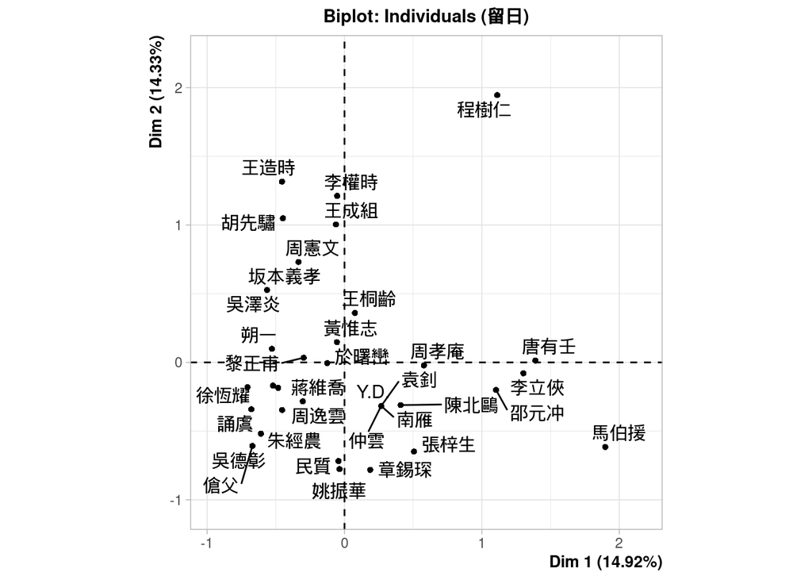

```r
plot.MCA(res.MCA,invisible= 'var',title="Biplot: Individuals (留日)", autoLab = "yes", label =c('ind'))
```

```r
# Statistics

dimdesc(res.MCA)
```

```
## $`Dim 1`
##
## Link between the variable and the categorical variable (1-way anova)
## =============================================
##                          R2      p.value
## Occupation        0.7709533 2.148266e-09
## Sentiment         0.4218280 1.024995e-05
## Topic             0.5135315 6.499835e-05
## Education Country 0.3818629 8.607131e-04
##
## Link between variable and the categories of the categorical variables
## ================================================================
##                                         Estimate      p.value
## Occupation=official-bureaucrat         1.1633233 4.228327e-08
## Sentiment=Negative                     0.4203240 1.024995e-05
## Education Country=Japan-USA            1.1050754 3.762293e-04
## Topic=T1. Sino-Japanese Tensions       0.4902976 2.864683e-03
## Topic=T3. Regulations/Petitions        0.6574203 1.252314e-02
## Occupation=Occupation.NA              -0.5183219 4.802206e-02
## Occupation=scholar                    -0.5934239 4.345915e-02
## Education Country=China-NA            -0.6037227 8.390405e-03
## Topic=T2. Education/Political Reforms -0.6425274 6.407185e-03
## Sentiment=Positive                    -0.4203240 1.024995e-05
##
## $`Dim 2`
##
## Link between the variable and the categorical variable (1-way anova)
## =============================================
##                          R2      p.value
## Education Country 0.7093506 3.052458e-09
## Occupation        0.6645913 7.827675e-07
## Topic             0.4276463 8.083377e-04
## Generation        0.1771280 8.508663e-03
##
## Link between variable and the categories of the categorical variables
## ================================================================
##                                         Estimate      p.value
## Education Country=USA                  1.1169567 1.395572e-09
## Occupation=scholar                     0.3925588 1.557418e-04
## Occupation=other                       1.7668460 1.222569e-03
```

[output cut: 21 more lines]

```
## Education Country=Japan-USA      0.9837227 0.0007376626
## Occupation=official-bureaucrat   0.8010895 0.0017044975
## Generation=Pre1895               0.2978747 0.0023895278
## Education Country=Japan          0.1281767 0.0129134879
## Sentiment=Positive               0.2445848 0.0142919370
## Topic=T5. Science/Society        0.4540580 0.0188378544
## Occupation=scholar-official      1.3086641 0.0220182770
## Occupation=scholar               0.2613957 0.0266810092
## Occupation=professional writer  -0.5554794 0.0449019649
## Topic=T3. Regulations/Petitions -0.4946911 0.0339162669
## Occupation=other                -1.4185423 0.0295543993
## Sentiment=Negative              -0.2445848 0.0142919370
## Occupation=Occupation.NA        -0.3971275 0.0119155003
## Generation=Post1895             -0.2978747 0.0023895278
## Education Country=China-NA      -0.6437582 0.0006121810
```

## Hierarchical Clustering

Finally, hierarchical clustering is applied to categorize authors based on shared characteristics:

```r
res.MCA<-MCA(liuri_mca,ncp=14,graph=FALSE)
res.HCPC<-HCPC(res.MCA,nb.clust=5,consol=FALSE,graph=FALSE)
```

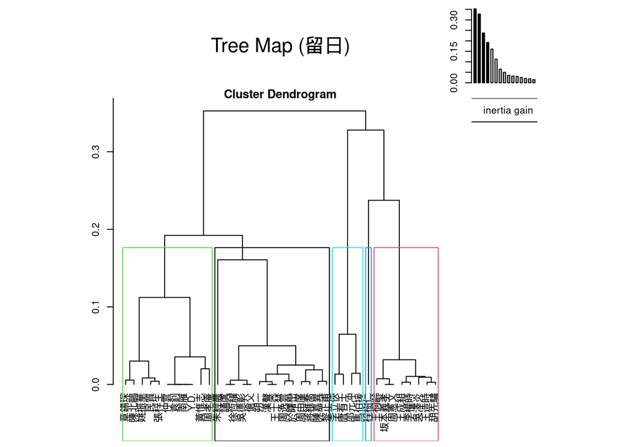

```r
# Plots

plot.HCPC(res.HCPC,choice='tree',title='Tree Map (留日)')
```

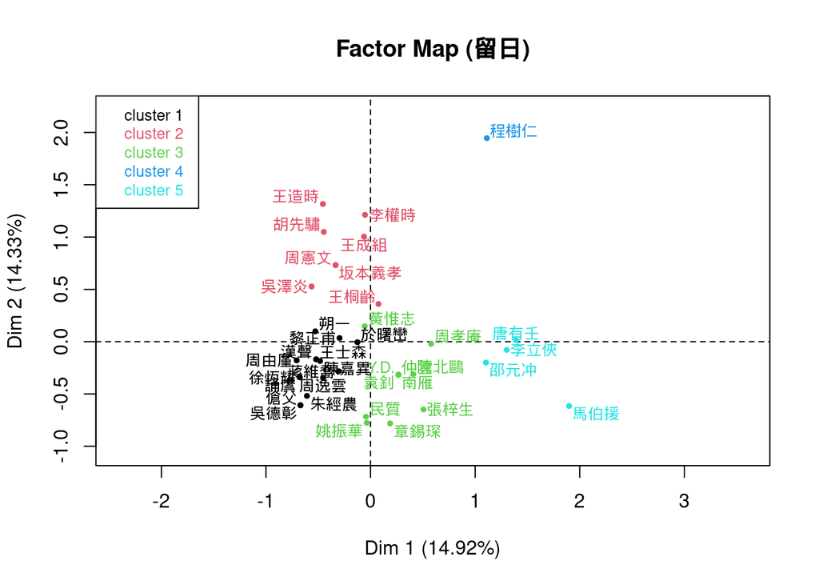

```r
plot.HCPC(res.HCPC,choice='map',draw.tree=FALSE,title='Factor Map (留日)')
```

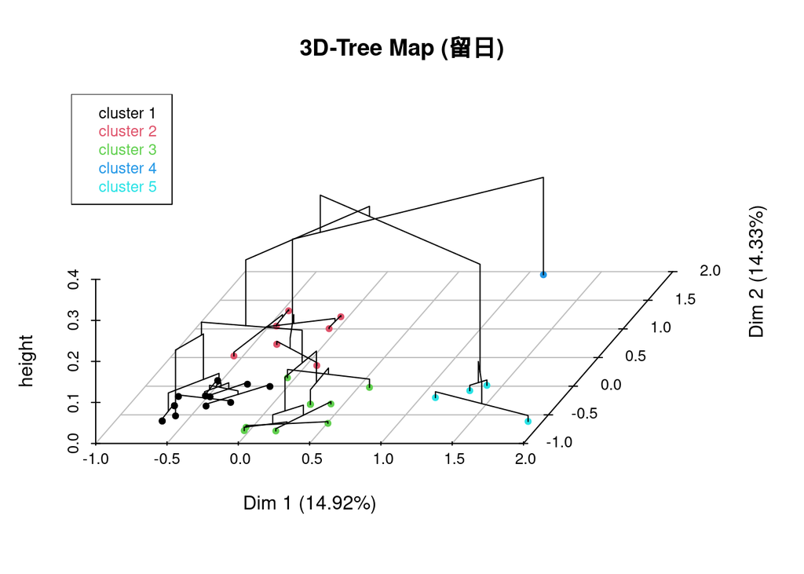

```r
plot.HCPC(res.HCPC,choice='3D.map',ind.names=FALSE,centers.plot=FALSE,angle=60,title='3D-Tree Map (留日)')
```

```r
# Statistics

summary(res.HCPC)
```

```
##            Length Class      Mode
## data.clust 6      data.frame list
## desc.var   3      catdes     list
## desc.axes  3      catdes     list
## desc.ind   2      -none-     list
## call       7      -none-     list
```

# Going Further

For a comparative perspective, please consult the [corresponding scripts](https://bookdown.enpchina.eu//dfzz_liuxue/liumei_authors.html) on American-returned students.